# Demo 5 (Robinson): Single-cell RNA-seq pipeline

based on scater’s and scran’s vignettes (modified by Anthony Sonrel, Lukas Weber, Stefan Milosavljevic, Almut Lütge, Helena L Crowell and Mark Robinson)

Compiled: June 02, 2022

# Introduction

This document demonstrates an analysis pipeline for single-cell RNA-sequencing (scRNA-seq) data. We will use the `scran` and `scater` R/[Bioconductor](https://bioconductor.org/) packages, together with the 10X Genomics 2700 peripheral blood mononuclear cells (PBMCs) dataset.

`scran` is a Bioconductor R package to perform low-level analyses of single-cell RNA-seq data, including normalization of cell-specific biases, assignment of cell cycle phase, detection of highly variable and significantly correlated genes, correction of batch effects, identification of marker genes, and other common tasks.

The 10X Genomics 2700 PBMCs dataset was made publicly available by 10X Genomics. It is used in the `Seurat` example vignettes, and is also available for download from the [Satija Lab website](https://satijalab.org/seurat/get_started.html).

The examples in this document are modified from the `scran` and `scater` vignettes [Using *scran* to analyze single-cell RNA-seq data](https://bioconductor.org/packages/release/bioc/vignettes/scran/inst/doc/scran.html) and [Data visualisation methods in *scater*](https://bioconductor.org/packages/release/bioc/vignettes/scater/inst/doc/vignette-dataviz.html), respectively. Another popular package in single-cell, which we will not present here given the time constraints, is the `Seurat` package which also has very good documentation (see [Guided Clustering Tutorial](https://satijalab.org/seurat/v3.0/pbmc3k_tutorial.html)).

## Single-cell RNA-seq data

This session will show you some aspects of how to analyze scRNAseq data. scRNAseq is a relatively young area of research (first article in 2009) that involves sequencing the transcriptome of each single-cell of a sample.

Like other sequencing pipelines (e.g. DNA sequencing), the raw data returned by the sequencing machine first needs to be processed in progressive steps: quality control, filtering, trimming, alignment, and so on.

Here we will directly load PBMC count data that are generated from sequencing reads using the *10x genomics* `cellranger` processing pipeline (*10x genomics* is one of the many technologies that perform scRNAseq):

```r
suppressPackageStartupMessages({
  library(scater)
  library(scran)
  library(DropletUtils)
  library(SingleCellExperiment)
  library(SingleR)
  library(celldex)
  library(pheatmap)
})
data_dir <- file.path("..", "data")

# Unzip data
untar(
  tarfile = file.path(data_dir,
                      "pbmc3k_filtered_gene_bc_matrices.tar.gz"),
  exdir = data_dir)

# Load data
pbmc.sce <- read10xCounts(samples = file.path(data_dir,
                                              "filtered_gene_bc_matrices", "hg19"),
                          col.names = TRUE, )
```

# The SingleCellExperiment object

By loading the data as above we have stored all data necessary to perform downstream analysis in one object called a `SingleCellExperiment` object. Most importantly, this object contains the count data (also called assay - see below) with per-cell counts for all genes in one matrix, as well as cell-related metadata (e.g., sample, batch, treatment, …) and gene-related metadata (e.g., gene symbol).

The `counts` assay of `pbmc.sce` is a “dgcMatrix”, a matrix that efficiently stores sparse matrices (most elements are zeros, represented by dots). You will see in the next sections that we can append multiple *assays* (e.g., raw counts, log-normalized expression). The genes (rows) are named after their gene identifiers (ENSEMBL IDs) and the cells after a tag chain. These DNA-tags were added during the sequencing protocol to differentiate cells and give them an ‘individual identity’.

Within all assays each column represent another cell and each row another gene. Thus you can find the cell names in the column names and cell-related metadata are stored in the `colData` while gene names correspond to rownames and gene-related metadata are stored in the `rowData`. We can use accessor functions to extract the information we need from the `SingleCellExperiment` object.

```r
# Have a look at the object
pbmc.sce
```

```
## class: SingleCellExperiment
## dim: 32738 2700
## metadata(1): Samples
## assays(1): counts
## rownames(32738): ENSG00000243485 ENSG00000237613 ... ENSG00000215616
##   ENSG00000215611
## rowData names(2): ID Symbol
## colnames(2700): AAACATACAACCAC-1 AAACATTGAGCTAC-1 ... TTTGCATGAGAGGC-1
##   TTTGCATGCCTCAC-1
## colData names(2): Sample Barcode
## reducedDimNames(0):
## mainExpName: NULL
## altExpNames(0):
```

```r
# As any matrix it has dimensions
dim(pbmc.sce)
```

```
## [1] 32738  2700
```

```r
# To get the count assay:
counts(pbmc.sce)[41:45,45:50]
```

```
## 5 x 6 sparse Matrix of class "dgCMatrix"
##                 AACAAACTCATTTC-1 AACAAACTTTCGTT-1 AACAATACGACGAG-1
## ENSG00000188290                .                .                .
## ENSG00000224969                .                .                .
## ENSG00000187608                .                .                .
## ENSG00000188157                .                .                .
## ENSG00000273443                .                .                .
##                 AACACGTGCAGAGG-1 AACACGTGGAAAGT-1 AACACGTGGAACCT-1
## ENSG00000188290                .                .                .
## ENSG00000224969                .                .                .
## ENSG00000187608                1                .                5
## ENSG00000188157                .                .                .
## ENSG00000273443                .                .                .
```

```r
# To get the cell names and cell metadata
head(colnames(pbmc.sce))
```

```
## [1] "AAACATACAACCAC-1" "AAACATTGAGCTAC-1" "AAACATTGATCAGC-1" "AAACCGTGCTTCCG-1"
## [5] "AAACCGTGTATGCG-1" "AAACGCACTGGTAC-1"
```

```r
# As you can see the colData themselves are stored in a DataFrame
head(colData(pbmc.sce))
```

```
## DataFrame with 6 rows and 2 columns
##                                  Sample          Barcode
##                             <character>      <character>
## AAACATACAACCAC-1 ../data/filtered_gen.. AAACATACAACCAC-1
## AAACATTGAGCTAC-1 ../data/filtered_gen.. AAACATTGAGCTAC-1
## AAACATTGATCAGC-1 ../data/filtered_gen.. AAACATTGATCAGC-1
## AAACCGTGCTTCCG-1 ../data/filtered_gen.. AAACCGTGCTTCCG-1
## AAACCGTGTATGCG-1 ../data/filtered_gen.. AAACCGTGTATGCG-1
## AAACGCACTGGTAC-1 ../data/filtered_gen.. AAACGCACTGGTAC-1
```

```r
# To get the gene names and gene metadata
head(rownames(pbmc.sce))
```

```
## [1] "ENSG00000243485" "ENSG00000237613" "ENSG00000186092" "ENSG00000238009"
## [5] "ENSG00000239945" "ENSG00000237683"
```

```r
head(rowData(pbmc.sce))
```

```
## DataFrame with 6 rows and 2 columns
##                              ID       Symbol
##                     <character>  <character>
## ENSG00000243485 ENSG00000243485   MIR1302-10
## ENSG00000237613 ENSG00000237613      FAM138A
## ENSG00000186092 ENSG00000186092        OR4F5
## ENSG00000238009 ENSG00000238009 RP11-34P13.7
## ENSG00000239945 ENSG00000239945 RP11-34P13.8
## ENSG00000237683 ENSG00000237683   AL627309.1
```

During downstream analysis we can use these object to retrieve all information we need and store intermediate or final results.

# Library sizes and Quality control

We can now look at the *library size*, the number of transcripts that were detected in all of the cells:

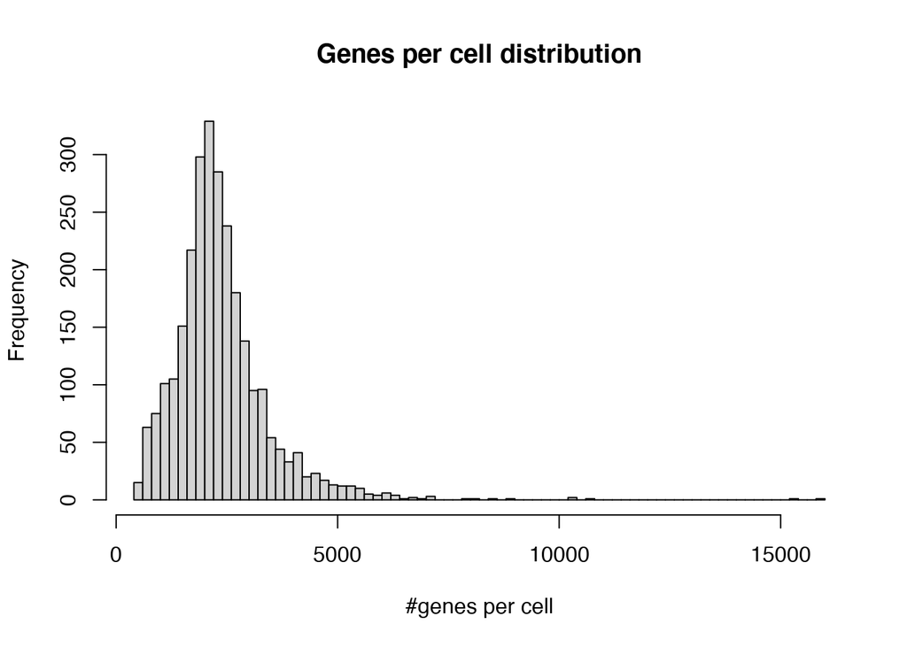

```r
hist(colSums(counts(pbmc.sce)), breaks = 100,
     xlab="#genes per cell",
     main = "Genes per cell distribution")
```

Most of the cells have a low library size (number of detected genes per cell) and only a few outliers have a high transcriptomic activity, which is typical of scRNAseq.

The first steps of our analysis need some basic statistics such as library size per cell or the mitochondrial gene content. These metadata can be generated with the `perCellQCMetrics` function. The results will then be added to the `colData` (column-specific metadata) of the sce:

```r
## various cell QC metrics
meta.data <- perCellQCMetrics(pbmc.sce,
                              subsets = list(Mito=grep("MT-",
                                                       rowData(pbmc.sce)$Symbol)))

colData(pbmc.sce) <- cbind(colData(pbmc.sce), meta.data)
head(colData(pbmc.sce))
```

```
## DataFrame with 6 rows and 8 columns
##                                  Sample          Barcode       sum  detected
##                             <character>      <character> <numeric> <integer>
## AAACATACAACCAC-1 ../data/filtered_gen.. AAACATACAACCAC-1      2421       781
## AAACATTGAGCTAC-1 ../data/filtered_gen.. AAACATTGAGCTAC-1      4903      1352
## AAACATTGATCAGC-1 ../data/filtered_gen.. AAACATTGATCAGC-1      3149      1131
## AAACCGTGCTTCCG-1 ../data/filtered_gen.. AAACCGTGCTTCCG-1      2639       960
## AAACCGTGTATGCG-1 ../data/filtered_gen.. AAACCGTGTATGCG-1       981       522
## AAACGCACTGGTAC-1 ../data/filtered_gen.. AAACGCACTGGTAC-1      2164       782
##                  subsets_Mito_sum subsets_Mito_detected subsets_Mito_percent
##                         <numeric>             <integer>            <numeric>
## AAACATACAACCAC-1               73                    10             3.015283
## AAACATTGAGCTAC-1              186                    10             3.793596
## AAACATTGATCAGC-1               28                     8             0.889171
## AAACCGTGCTTCCG-1               46                    10             1.743085
## AAACCGTGTATGCG-1               12                     5             1.223242
## AAACGCACTGGTAC-1               36                     7             1.663586
##                      total
##                  <numeric>
## AAACATACAACCAC-1      2421
## AAACATTGAGCTAC-1      4903
## AAACATTGATCAGC-1      3149
## AAACCGTGCTTCCG-1      2639
## AAACCGTGTATGCG-1       981
## AAACGCACTGGTAC-1      2164
```

# Overview of the pipeline

The analysis pipeline can be roughly divided into 3 parts -  
pre-processing, dimensionality reduction and visualization, and differential analyses:

1. Pre-processing
   - Quality control (QC) and filtering
   - Normalization
   - Selection of highly variable genes
   - Removing unwanted sources of variation
2. Dimensionality reduction and visualization
   - Principal Component Analysis (PCA)
   - Clustering
   - tSNE
3. Downstream analyses

# Pre-processing

Pre-processing steps for scRNA-seq data include:

- Filtering cells and/or genes based on quality control (QC) metrics
- Data normalization and scaling
- Selection of highly variable genes: these are the “interesting” genes that are used in downstream analyses
- Removing unwanted sources of variation (if necessary)

## Quality control (QC) and filtering

Filtering can be used to exclude cells or genes that do not meet QC metrics. A common filtering step is based on the total count for each cell and the mitochondrial content:

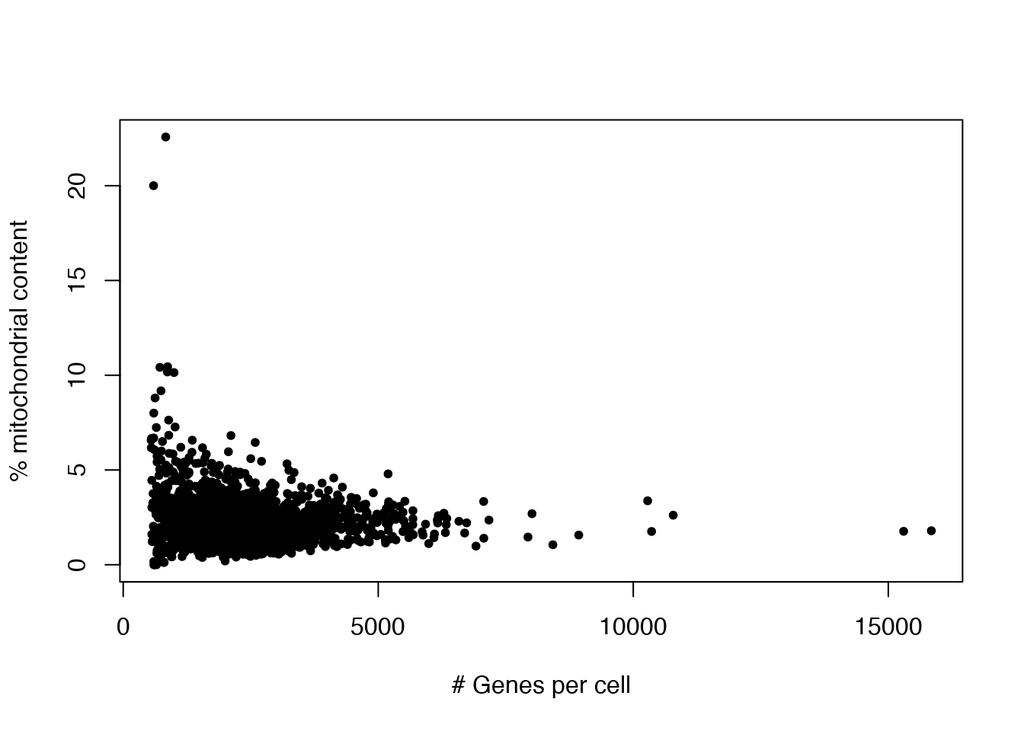

```r
plot(pbmc.sce$sum, pbmc.sce$subsets_Mito_percent, pch = 20,
     xlab = "# Genes per cell",
     ylab = "% mitochondrial content")
```

We can first exclude cells with a clear outlier number of genes detected; these are assumed to be doublets or multiplets (two or more cells sequenced as a single cell) or debris of cells (resulting in low counts). We also filter cells based on the percentage of mitochondrial genes; a high percentage of mitochondrial genes usually indicate damages to the cell due to loss of cytoplasm.

For both metrics, the `isOutlier` function can be used to detect outliers cells based on the deviation to a median absolute value (MAD);

```r
## outliers of detected genes
outliers.ngenes <- isOutlier(pbmc.sce$sum, type="both", log=TRUE)
table(outliers.ngenes)
```

```
## outliers.ngenes
## FALSE  TRUE
##  2595   105
```

```r
## Same for mitochondrial content
outliers.mito <- isOutlier(pbmc.sce$subsets_Mito_percent, type="higher", log=TRUE)
table(outliers.mito)
```

```
## outliers.mito
## FALSE  TRUE
##  2686    14
```

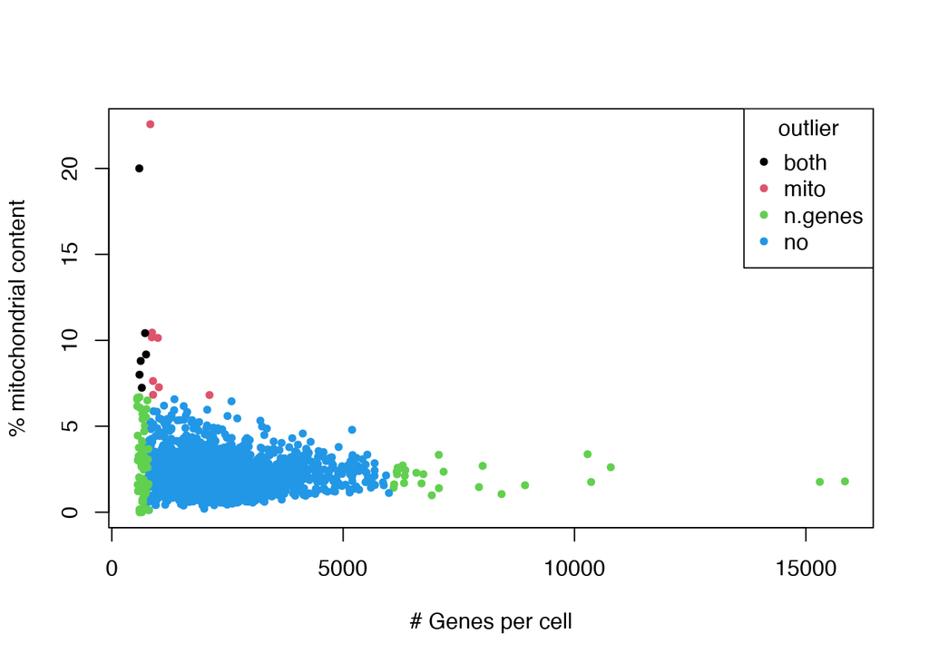

```r
outliers.sum <- ifelse(outliers.ngenes, ifelse(outliers.mito, "both", "n.genes"), ifelse(outliers.mito, "mito", "no") )

plot(pbmc.sce$sum, pbmc.sce$subsets_Mito_percent, pch = 20,
     col = factor(outliers.sum),
     xlab = "# Genes per cell", ylab = "% mitochondrial content")
legend("topright", legend = levels(factor(outliers.sum)),
  col = 1:length(unique(outliers.sum)),
  pch = 20, title = "outlier")
```

```r
pbmc.sce <- pbmc.sce[,!(outliers.mito | outliers.ngenes)]
dim(pbmc.sce)
```

```
## [1] 32738  2587
```

Finally we can remove features that are not expressed in any cells:

```r
feats.to.keep <- nexprs(pbmc.sce, byrow=TRUE) > 0
table(feats.to.keep)
```

```
## feats.to.keep
## FALSE  TRUE
## 16247 16491
```

```r
pbmc.sce <- pbmc.sce[feats.to.keep,]
dim(pbmc.sce)
```

```
## [1] 16491  2587
```

Of note, these filtering settings are rather arbitrary and simplistic: it is still an active field of research and many packages have been developed to this end.

## Normalization and scaling

We use the normalization method `logNormCounts`, which normalizes the gene expression measurements for each cell by their size factor followed by a log-transformation (with an additional pseudo-count of 1 to handle zeros). Normalized data are stored in a new assay, `logcounts` (which can be accessed with a function of the same name).

```r
# Normalization
pbmc.sce <- logNormCounts(pbmc.sce)
assayNames(pbmc.sce)
```

```
## [1] "counts"    "logcounts"
```

```r
# access the assay
logcounts(pbmc.sce)[41:45,45:50]
```

```
## 5 x 6 sparse Matrix of class "dgCMatrix"
##                 AACAAACTTTCGTT-1 AACAATACGACGAG-1 AACACGTGCAGAGG-1
## ENSG00000160075                .          .                      .
## ENSG00000215014                .          .                      .
## ENSG00000228594                .          .                      .
## ENSG00000272106                .          .                      .
## ENSG00000197530                .          1.08724                .
##                 AACACGTGGAAAGT-1 AACACGTGGAACCT-1 AACACGTGGCTACA-1
## ENSG00000160075                .                .        0.9198642
## ENSG00000215014                .                .        .
## ENSG00000228594                .                .        .
## ENSG00000272106                .                .        .
## ENSG00000197530                .                .        .
```

## Selection of highly variable genes

As many other processing packages, `scran` detects highly variable genes and focuses on these for the downstream analysis. This can be done with `getTopHVGs`. Here we will select the 2000 top variable genes:

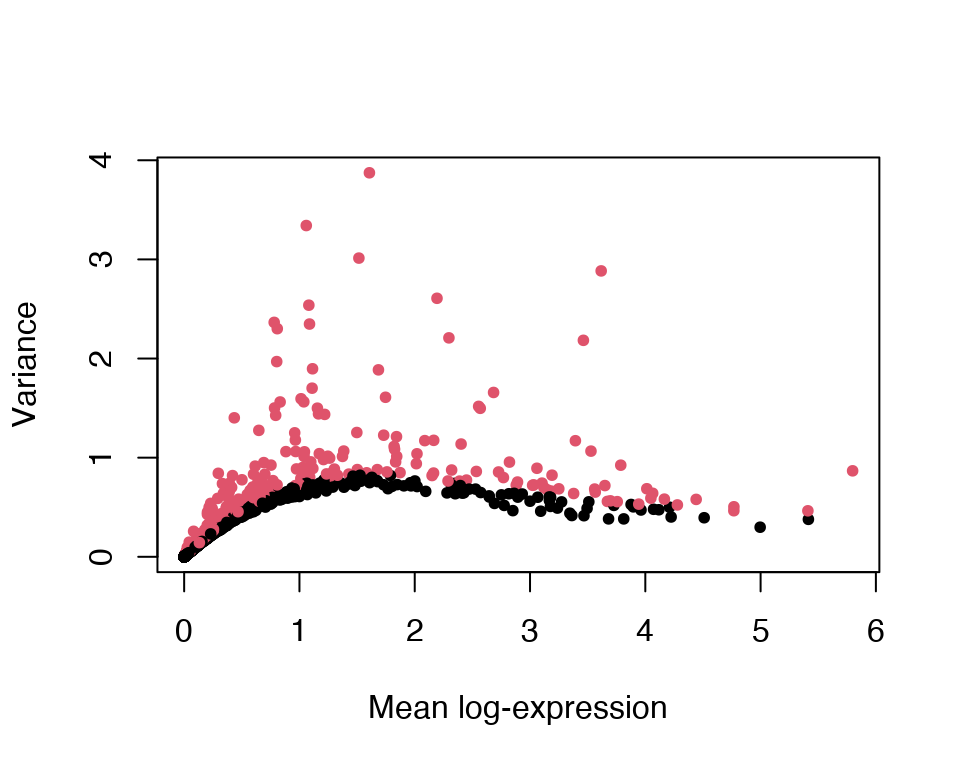

```r
# Find highly variable genes
dec <- modelGeneVar(pbmc.sce)
top.hvgs <- getTopHVGs(dec, n = 2000)
is.hvgs <- rownames(pbmc.sce) %in% top.hvgs + 1
plot(dec$mean, dec$total, xlab="Mean log-expression", ylab="Variance", col = is.hvgs, pch = 20)
```

Most scRNAseq data exhibits this mean-variance relationship (higher average expression is associated with higher variability up to a plateau) and `getTopHVGs` ranks the genes by accounting for this relationship.

# Dimensionality reduction & visualization

## Principal Component Analysis (PCA)

Next, we perform principal component analysis (PCA, linear dimensionality reduction) on the pre-processed data. For more accuracy, the PCA is performed on the HVGs that we identified in the previous section. The result can be accessed with `reducedDim`.

```r
# PCA
pbmc.sce <- runPCA(pbmc.sce, subset_row = top.hvgs)
reducedDimNames(pbmc.sce)
```

```
## [1] "PCA"
```

```r
head(reducedDim(pbmc.sce))[,1:3]
```

```
##                        PC1         PC2        PC3
## AAACATACAACCAC-1 -5.511639  -0.2553097  2.2678167
## AAACATTGAGCTAC-1 -2.079025   5.7537708 -5.2173622
## AAACATTGATCAGC-1 -4.004750  -2.0708380  3.0352766
## AAACCGTGCTTCCG-1 13.430830   1.8109118 -0.6837795
## AAACCGTGTATGCG-1  2.288813 -10.7617927 -8.0167221
## AAACGCACTGGTAC-1 -3.093118  -0.8845514  1.4957724
```

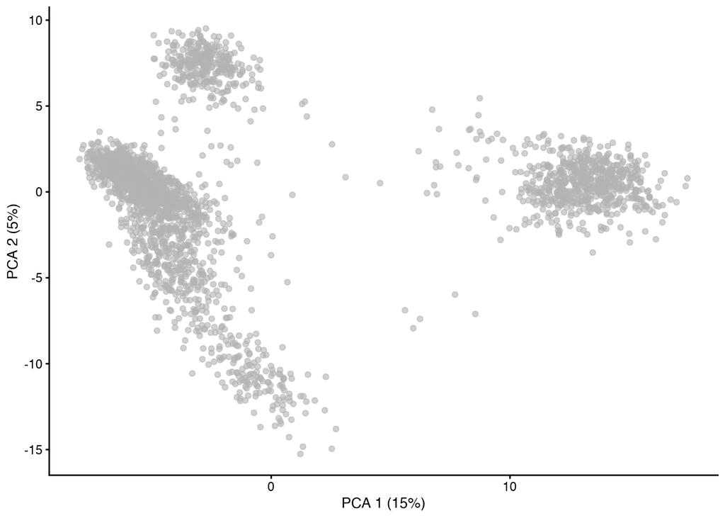

```r
plotPCA(pbmc.sce)
```

Although PCA is often used for visualization purpose in other fields of research, its aim in scRNAseq is mainly to help clustering. Due to the non-linear nature of scRNAseq data, other methods of visualization are typically more effective (shown in the next sections).

## Clustering

`scran` includes a graph-based clustering method. Cells are embedded in a graph structure - for example, a shared nearest neighbours (SNN) graph, based on the local density of points. The determination of neighbours generation of the graph is computed on the PCA reduction that we performed before.

```r
g <- buildSNNGraph(pbmc.sce, use.dimred="PCA")
cluster <- igraph::cluster_fast_greedy(g)$membership
pbmc.sce$cluster <- factor(cluster)
table(pbmc.sce$cluster)
```

```
##
##    1    2    3    4
##  463 1160  326  638
```

## t-SNE and UMAP

The ‘tSNE’ algorithm (nonlinear dimensionality reduction) is widely used to visualize single-cell RNA-seq and CyTOF datasets.

While PCA aims to preserve the variance in the data, tSNE is designed to maintain the neighborhood of data points. This facilitates 2-dimensional visualization of groups/clusters of cells with similar transcription profiles, which helps to identify cell populations. However, it can also be harder to interpret than PCA. This is because: (i) the tSNE dimensions do not have an underlying meaning, (ii) re-runs using different random seeds generate different plots, and (iii) only local distances on the plot are meaningful (i.e. two clusters that are “further away” are not necessarily more distinct).

‘UMAP’ (Uniform Manifold Approximation and Projection) is another non-linear dimensionality reduction technique. It has shown to improve tSNE in terms of runtime, consistency, meaningful organization of cell clusters and preservation of continuums.

```r
# Run tSNE
set.seed(1234)
pbmc.sce <- runTSNE(pbmc.sce,
  components = 2, ntop = 500,
  exprs_values = "logcounts")

# Run UMAP
pbmc.sce <- runUMAP(pbmc.sce,
  ncomponents = 2, ntop = 500,
  exprs_values = "logcounts")
```

To plot the reduced dimensions single or multiplot layouts can be used. Any colData variable can be plotted aside defined by `colour_by`.

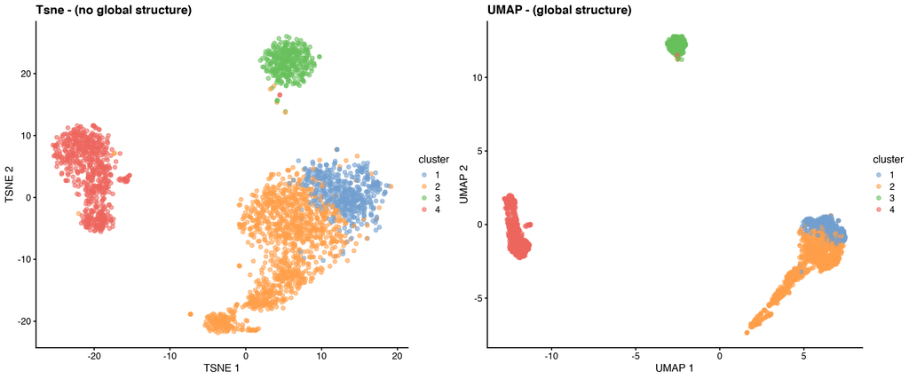

```r
multiplot(cols = 2,
  plotTSNE(pbmc.sce, colour_by = "cluster") +
    ggtitle("Tsne - (no global structure)"),
  plotUMAP(pbmc.sce, colour_by = "cluster") +
    ggtitle("UMAP - (global structure)"))
```